# 0124

## Creating indicator (dummy) variables

To include a categorical variable in a regression, you most often need to construct a series of indicator variables for all but one of the categories contained in that variable. Many of the analystical functions in R (such as `lm()`, which performs an OLS linear regression) will do this conversion automatically, trying to pick a good value for the reference category. But very often you will need to make indicator variables yourself. We'll look at ways to do that here.

We will start with a slightly different dataset than last week. It is from the same database, but is a much smaller sample, from 2016 rather than 2017, and contains several additional variables.

```r
d <- read.csv("https://mcmahanp.github.io/soci620/data/USincome_subset_2016.csv")
summary(d)
```

```
       id           family_size     children_in_hh       female
 Min.   :   1545   Min.   : 1.000   Min.   :0.0000   Min.   :0.0000
 1st Qu.: 807813   1st Qu.: 2.000   1st Qu.:0.0000   1st Qu.:0.0000
 Median :1592909   Median : 2.000   Median :0.0000   Median :1.0000
 Mean   :1598862   Mean   : 2.831   Mean   :0.6637   Mean   :0.5104
 3rd Qu.:2392786   3rd Qu.: 4.000   3rd Qu.:1.0000   3rd Qu.:1.0000
 Max.   :3156468   Max.   :16.000   Max.   :7.0000   Max.   :1.0000

      age                        marital_status times_married
 Min.   :15.00   Divorced               : 416   Min.   :0.0000
 1st Qu.:32.00   Married, spouse absent :  90   1st Qu.:0.0000
 Median :47.00   Married, spouse present:1576   Median :1.0000
 Mean   :47.68   Never married/single   : 965   Mean   :0.9119
 3rd Qu.:61.00   Separated              :  67   3rd Qu.:1.0000
 Max.   :96.00   Widowed                : 199   Max.   :3.0000

                              race         hispanic           hispanic_origin
 White                          :2463   Min.   :0.00000   Cuban       :   8
 Black/African American/Negro   : 396   1st Qu.:0.00000   Mexican     : 307
 Other Asian or Pacific Islander: 160   Median :0.00000   Not Hispanic:2834
 Other race, nec                : 140   Mean   :0.05192   Other       : 113
 Two major races                :  67   3rd Qu.:0.00000   Puerto Rican:  51
 Chinese                        :  43   Max.   :1.00000
 (Other)                        :  44
   health_ins     health_ins_priv  health_ins_employer   in_school
 Min.   :0.0000   Min.   :0.0000   Min.   :0.000       Min.   :0.0000
 1st Qu.:1.0000   1st Qu.:0.0000   1st Qu.:0.000       1st Qu.:0.0000
 Median :1.0000   Median :1.0000   Median :1.000       Median :0.0000
 Mean   :0.9107   Mean   :0.7114   Mean   :0.569       Mean   :0.1087
 3rd Qu.:1.0000   3rd Qu.:1.0000   3rd Qu.:1.000       3rd Qu.:0.0000
 Max.   :1.0000   Max.   :1.0000   Max.   :1.000       Max.   :1.0000

 ed_highschool      ed_college         income        poverty
 Min.   :0.0000   Min.   :0.0000   Min.   :     4   Mode :logical
 1st Qu.:1.0000   1st Qu.:0.0000   1st Qu.: 13000   FALSE:2911
 Median :1.0000   Median :0.0000   Median : 28000   TRUE :340
 Mean   :0.8952   Mean   :0.1155   Mean   : 44506   NA's :62
 3rd Qu.:1.0000   3rd Qu.:0.0000   3rd Qu.: 55000
 Max.   :1.0000   Max.   :1.0000   Max.   :747000
 NA's   :49       NA's   :49
   occ_income      log_income
 Min.   : 3.00   Min.   : 1.386
 1st Qu.:20.00   1st Qu.: 9.473
 Median :25.00   Median :10.240
 Mean   :27.69   Mean   :10.106
 3rd Qu.:35.00   3rd Qu.:10.915
 Max.   :80.00   Max.   :13.524
 NA's   :643
```

#### Binary categories

We will start with the construction of simple, binary indicators. These are variables that have only two categories: married versus not married; over 35 years old versus 35 years old and younger. You can construct these variables with simple logical tests in R.

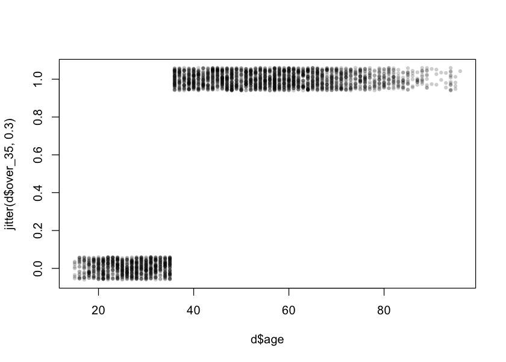

```r
# anyone with age > 35
# `d$age > 35` gives us a vector of TRUE and FALSE values
# `as.numeric()` converts that to a vector of 1s and 0s
d$over_35 <- as.numeric(d$age > 35)

# note: another way you may see this done is with the `ifelse()` function:
#d$over_35 <- ifelse(d$age > 35, 1, 0)

# set up plot window
options(repr.plot.height=5)
# plot age against our new variable
# (the `jitter` function adds some random noise to a variable,
#  which can help variables with only a few, discrete values
#  easier to read on a plot)
plot(d$age,jitter(d$over_35,.3),pch=16,cex=.7,col='#00000033')

# compare to the same plot without jitter
#plot(d$age,d$over_35,pch=16,cex=.7,col='#00000033')
```

Now we will construct a single `married` variable from the `marital_status` variable.

```r
# what are the current categories in `marital_status`
table(d$marital_status)
```

```
               Divorced  Married, spouse absent Married, spouse present
                    416                      90                    1576
   Never married/single               Separated                 Widowed
                    965                      67                     199
```

```r
# we want to find respondents who are "Married, spouse absent" or "Married, spouse present"
married_categories <- c("Married, spouse absent","Married, spouse present")

# the speial `%in%` operator asks whether values in the first argument are
# present anywhere in the second argument
d$married <- as.numeric(d$marital_status %in% married_categories)

# compare the two variables to make sure it was right
table(d$marital_status,d$married)
```

```
                             0    1
  Divorced                 416    0
  Married, spouse absent     0   90
  Married, spouse present    0 1576
  Never married/single     965    0
  Separated                 67    0
  Widowed                  199    0
```

#### Variables with more than two categories

Very often, we want to keep all of the categories in a variable like `marital_status` for use in a regression. To do this, you need to first pick one *reference category* against which the others will be compared. You then construct indicator variables for each of the other categories.

We will do this for `marital_status`. There is no one obvious choice for a reference category here, and it often depends on your research question. Are we interested in how things are distinctive for people who have never been married? Then "Never married/single" is probably a good reference category. Or are we concerned with how the job market is different for people in a cohabitating, "nuclear" family situation than it is for people in other living situations? In that case "Married, spouse present" makes more sense as a reference category. In general, it is usually a good idea for the reference category to be well represented in the data, so using "Separated" as the reference here (only 67 cases in our data) is probably not appropriate.

We will use "Never married/single" as our reference here.

```r
# For a variable with only a few categories, it's often easies to construct
# each indicator on its own:
d$m_divorced <- as.numeric(d$marital_status=='Divorced')
d$m_spouse_absent <- as.numeric(d$marital_status=='Married, spouse absent')
d$m_spouse_present <- as.numeric(d$marital_status=='Married, spouse present')
d$m_separated <- as.numeric(d$marital_status=='Separated')
d$m_widowed <- as.numeric(d$marital_status=='Widowed')
```

```r
# use the `unique()` function to make sure we got this right
unique(d[c('marital_status','m_divorced','m_spouse_absent','m_spouse_present','m_separated','m_widowed')])
# how this works:
# first: `d[c('a','b')]` returns the data frame `d`, bun only with columns named 'a' and 'b'
# second: `unique(d)` shows only rows in `d` that are unique (dropping repeated, identical rows)
```

|  | marital_status | m_divorced | m_spouse_absent | m_spouse_present | m_separated | m_widowed |
| --- | --- | --- | --- | --- | --- | --- |
| 1 | Married, spouse present | 0 | 0 | 1 | 0 | 0 |
| 2 | Never married/single | 0 | 0 | 0 | 0 | 0 |
| 3 | Widowed | 0 | 0 | 0 | 0 | 1 |
| 5 | Separated | 0 | 0 | 0 | 1 | 0 |
| 8 | Divorced | 1 | 0 | 0 | 0 | 0 |
| 53 | Married, spouse absent | 0 | 1 | 0 | 0 | 0 |

#### Including these in a regression

Now that we have indicator variables, it is easy to include them in a regression:

```r
library(rethinking)
mfit <- map(alist(
    log_income ~ dnorm(mu,sigma),
    mu <- a + b_35*over_35 + b_divorced*m_divorced + b_spouse_absent*m_spouse_absent +
          b_spouse_present*m_spouse_present + b_separated*m_separated + b_widowed*m_widowed,
    a ~ dnorm(0,20),
    b_35 ~ dnorm(0,20),
    b_divorced ~ dnorm(0,20),
    b_spouse_absent ~ dnorm(0,20),
    b_spouse_present ~ dnorm(0,20),
    b_separated ~ dnorm(0,20),
    b_widowed ~ dnorm(0,20),
    sigma ~ dunif(0,25)
),data=d)
precis(mfit,prob=.95)
```

[output not shown]

```
                 Mean StdDev  2.5% 97.5%
a                9.46   0.04  9.38  9.54
b_35             0.42   0.05  0.32  0.53
b_divorced       0.38   0.07  0.23  0.52
b_spouse_absent  0.02   0.13 -0.23  0.27
b_spouse_present 0.63   0.06  0.52  0.74
b_separated      0.36   0.15  0.07  0.65
b_widowed        0.02   0.10 -0.17  0.21
sigma            1.16   0.01  1.13  1.18
```

Often, visualizing a table like this can help.

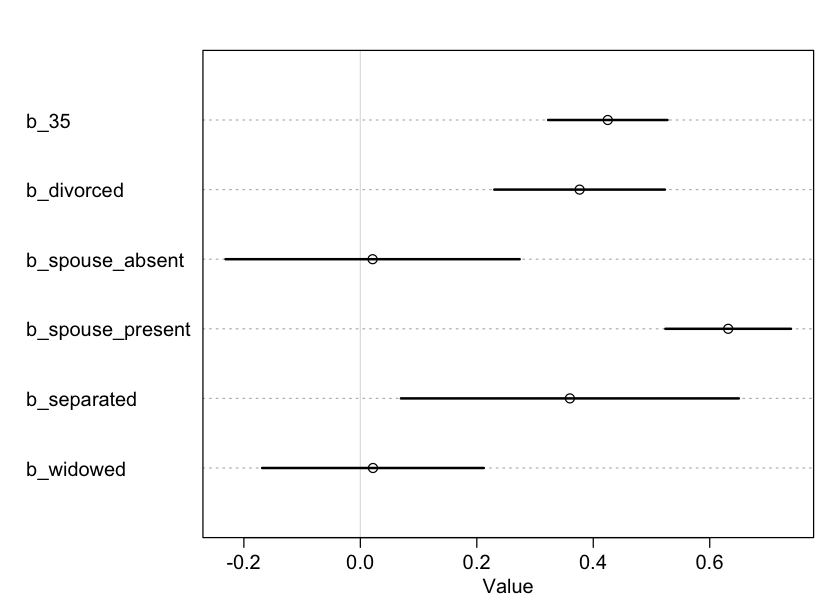

```r
plot(
    precis(
        mfit,prob=.95,
        pars = c('b_35','b_divorced','b_spouse_absent','b_spouse_present','b_separated','b_widowed')
    )
)
```

## Standardizing variables

Standardizing variables is often vital for regression analysis. Standardized variables have zero mean and unit standard deviation, which can help immensely in the interpretation of regression coefficients.

It is simple to standardize a variable: simply subtract the variable's mean and divide the result by the variable's standard deviation.

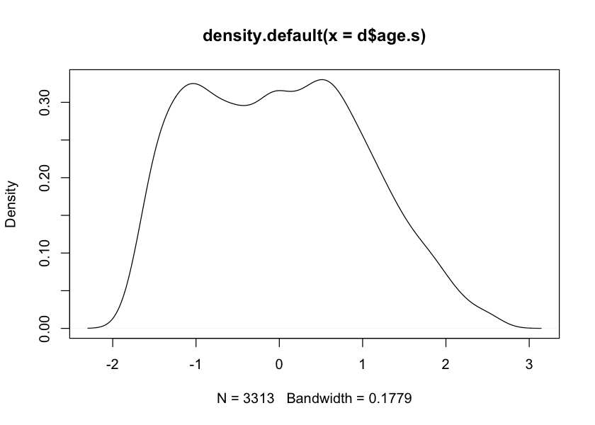

```r
d$age.s <- (d$age - mean(d$age))/sd(d$age)
plot(density(d$age.s))
```

You can create a simple *function* in R that will make this process easier.

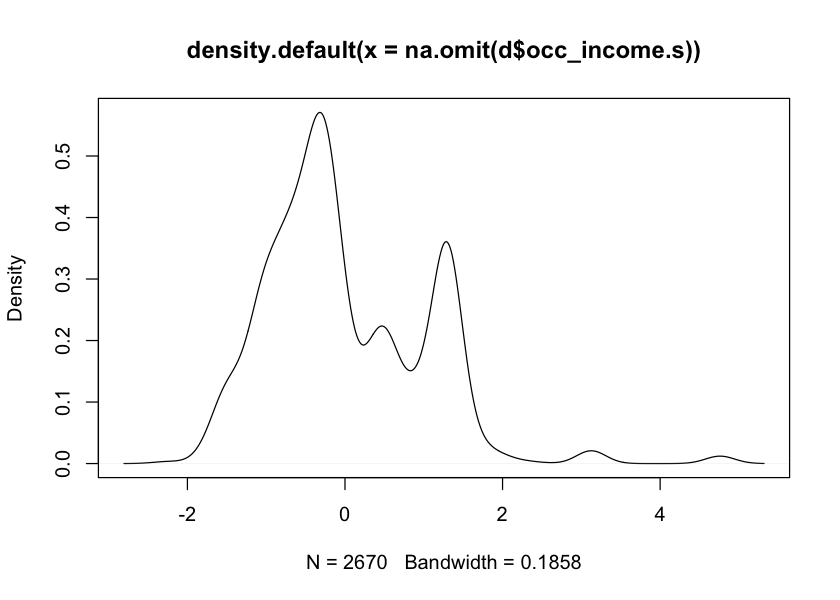

```r
st <- function(x){
    (x-mean(x,na.rm=TRUE))/sd(x,na.rm=TRUE)
}
d$occ_income.s <- st(d$occ_income)
plot(density(na.omit(d$occ_income.s)))
```

```r
# occ_income has missing values, so we first find
# rows with complete cases
comp <- complete.cases(d[c('log_income','age.s','occ_income.s')])
# now we fit a model, using `data=d[comp,]`
mfit <- map(alist(
    log_income ~ dnorm(mu,sigma),
    mu <- a + b_a*age.s + b_o*occ_income.s + b_ao*age.s*occ_income.s,
    a ~ dnorm(0,10),
    b_a ~ dnorm(0,10),
    b_o ~ dnorm(0,10),
    b_ao ~ dnorm(0,10),
    sigma ~ dunif(0,20)
),data=d[comp,])
precis(mfit,prob=.95)
```

```
       Mean StdDev  2.5% 97.5%
a     10.36   0.02 10.31 10.40
b_a    0.42   0.03  0.37  0.47
b_o    0.46   0.02  0.42  0.50
b_ao  -0.06   0.03 -0.12 -0.01
sigma  1.07   0.01  1.04  1.09
```